# raport

Autor: Tomasz Mazur  
Index: 401133

## Wstęp - opis zbioru danych

Do analizy został wykorzystany zbiór danych zawierający informacje na temat pacjentów, którym wykonano badanie kości pod względem możliwej osteoporozy. Zbiór składa się z 169 rekordów. Każdy z nich zawiera dane jednej osoby tj. dane personalne jak wiek, płeć oraz dane związane z ich zdrowiem tj. waga, stopień złamania itp. Najważniejszymi informacjami w tym zbiorze są:

- wskaźnik `bmd` (z ang. *bone mineral density*) - określa poziom wapnia oraz innych typów minerałów w obszarze kości. Jego wartość pozwala wykryć osteoporozę a także przewidzieć ryzyko złamania kości.
- zmienna `fracture` - określa czy u danego pacjenta doszło do złamania, czy nie
- pozostałe zmienne dotyczące samego pacjenta (tj. wiek, płeć itp) oraz sposobu leczenia

#### Wczytanie zbioru danych i wyświetlenie pierwszych 5 wierszy

```python
import pandas as pd
df = pd.read_csv('data/bmd_prep.csv')
df.head()
```

|  | age | sex | fracture | weight_kg | height_cm | medication | waiting_time | bmd |
| --- | --- | --- | --- | --- | --- | --- | --- | --- |
| 0 | 57.052768 | F | no fracture | 64.0 | 155.5 | Anticonvulsant | 18 | 0.8793 |
| 1 | 75.741225 | F | no fracture | 78.0 | 162.0 | No medication | 56 | 0.7946 |
| 2 | 70.778900 | M | no fracture | 73.0 | 170.5 | No medication | 10 | 0.9067 |
| 3 | 78.247175 | F | no fracture | 60.0 | 148.0 | No medication | 14 | 0.7112 |
| 4 | 54.191877 | M | no fracture | 55.0 | 161.0 | No medication | 20 | 0.7909 |

#### W ramach analizy zostały sformułowane dwie hipotezy badawcze:

1. Czy płeć, wiek i waga pacjenta wpływają na wartość wskaźnika `bmd`?
- zmienne opisujące (niezależne): `sex` (jak.), `age` (il.), `weight_kg` (il.)
- zmienna objaśniana (zależna): `bmd` (il.)
2. Czy rodzaj leczenia, wiek i wartość wskaźnika `bmd` pozwalają przewidzieć, czy wystąpi złamanie (`fracture`) czy nie?
- zmienne opisujące (niezależne): `medication` (jak.), `age` (il.), `bmd` (il.)
- zmienna objaśniana (zależna): `fracture` (jak.)

## **Hipoteza 1** - badanie zależności płci, wieku i wagi na wskaźnik `bmd` osoby dorosłej

### Badanie struktury populacji

```python
# Potrzebne biblioteki
import numpy as np
import matplotlib.pyplot as plt
```

#### 1. Statystyki opisowe - zmienne ilościowe

```python
numeric_vars = ['age', 'weight_kg', 'bmd']
np.round(df[numeric_vars].describe(),3)
```

|  | age | weight_kg | bmd |
| --- | --- | --- | --- |
| count | 169.000 | 169.000 | 169.000 |
| mean | 63.632 | 64.666 | 0.783 |
| std | 12.357 | 11.537 | 0.167 |
| min | 35.814 | 36.000 | 0.408 |
| 25% | 54.424 | 56.000 | 0.671 |
| 50% | 63.488 | 64.500 | 0.786 |
| 75% | 72.081 | 73.000 | 0.889 |
| max | 88.754 | 96.000 | 1.362 |

Najstarsza osoba w zbiorze ma niemal 89 lat natomiast najmłodsza niecałe 36. Waga pacjentów mieści się w zakresie od 36 do 96 kg. Średnia wartość wskaźnika `bmd` wynosi 0.783 a mediana 0.786.

wariancja

```python
np.round(df[numeric_vars].var(), 3)
```

```
age          152.694
weight_kg    133.106
bmd            0.028
dtype: float64
```

moda

```python
np.round(df[numeric_vars].mode(), 3)
```

|  | age | weight_kg | bmd |
| --- | --- | --- | --- |
| 0 | 35.814 | 55.0 | 0.690 |
| 1 | 36.648 | 59.0 | 0.713 |
| 2 | 37.462 | 62.0 | 0.889 |
| 3 | 39.255 | NaN | NaN |
| 4 | 40.232 | NaN | NaN |
| ... | ... | ... | ... |
| 164 | 85.902 | NaN | NaN |
| 165 | 86.860 | NaN | NaN |
| 166 | 87.935 | NaN | NaN |
| 167 | 88.024 | NaN | NaN |
| 168 | 88.754 | NaN | NaN |

169 rows × 3 columns

Najczęsciej występujące w zbiorze wagi pacjentów to 55, 59 i 62 kg.

#### 2. Tabele liczności - zmienne jakościowe

```python
categorical_vars = 'sex'
df[categorical_vars].value_counts()
```

```
M    86
F    83
Name: sex, dtype: int64
```

Dane cechują się równomiernym rozkładem pod względem płci - podobna ilość mężczyzn i kobiet

#### 3. Tabela wielodzielcza

```python
# group values in numeric features to equal ranges
df = pd.read_csv('data/bmd_prep.csv')
df['age'] = pd.cut(df['age'], 6, precision=0)
df['weight_kg'] = pd.cut(df['weight_kg'], 3, precision=0)

pivot = np.round(pd.pivot_table(df, values='bmd',
                                index=['sex','weight_kg', ],
                                columns=['age'],
                                aggfunc=['mean'],
                                margins=True,
                                margins_name='Checksum',
                                fill_value='-'),2)
pivot
```

| sex | age weight_kg | mean (36.0, 45.0] | mean (45.0, 53.0] | mean (53.0, 62.0] | mean (62.0, 71.0] | mean (71.0, 80.0] | mean (80.0, 89.0] | mean Checksum |
| --- | --- | --- | --- | --- | --- | --- | --- | --- |
| F | (36.0, 56.0] | 0.8888 | 0.71702 | 0.671383 | 0.700929 | 0.584114 | 0.551625 | 0.6568 |
|  | (56.0, 76.0] | - | 0.825856 | 0.828788 | 0.798714 | 0.5757 | 0.8171 | 0.790464 |
|  | (76.0, 96.0] | - | - | 0.85175 | 0.720533 | 0.6518 | 0.9061 | 0.75935 |
| M | (36.0, 56.0] | 0.762 | - | 0.756567 | 0.64615 | 0.5287 | 0.61185 | 0.675612 |
|  | (56.0, 76.0] | 1.027325 | 0.822356 | 0.860767 | 0.807264 | 0.839067 | 0.7478 | 0.838392 |
|  | (76.0, 96.0] | 0.88595 | 0.89415 | 0.92668 | 0.9745 | 1.0015 | 0.70525 | 0.917216 |
| Checksum |  | 0.892545 | 0.808292 | 0.823289 | 0.800995 | 0.694108 | 0.674905 | 0.783104 |

#### 4. Histogram dla zmiennej `bmd` skategoryzowany względem płci (`sex`)

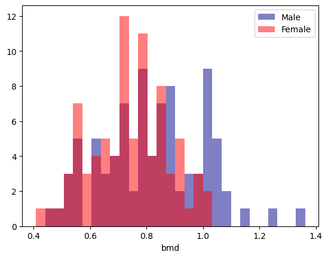

```python
df = pd.read_csv('data/bmd_prep.csv')
dependent_var = 'bmd'
grouping_var = 'sex'

min = df[dependent_var].min()
max = df[dependent_var].max()
bins = np.linspace(min, max, 30)

bmd_male = df.loc[df[grouping_var]=='M', dependent_var]
bmd_female = df.loc[df[grouping_var]=='F', dependent_var]

plt.hist(bmd_male, bins, alpha=0.5, label='Male', color='darkblue')
plt.hist(bmd_female, bins, alpha=0.5, label='Female', color='red')
plt.legend(loc='upper right')
plt.xlabel(dependent_var)
plt.show()
```

Na otrzymanym histogramie możemy zauważyć, że rozkład wartości wskaźnika `bmd` dla kobiet jest bardziej jednorodny niż w przypadku mężczyzn. Wartości mieszczą się w zakresie od 0.42 do 1.02. Natomiast u mężczyzn rozkład ten jest większy - rozkład jest bardziej przesunięty w prawo, gdzie mężczyźni mają wskaźnik `bmd` większy niż 1. Modalna wartość `bmd` dla kobiet wynosi około 0.75, a dla mężczyzn 0.78 oraz 1.04.

#### 5. Wykres interakcji (wykres średnich `bmd` w zależnosi od wieku i płci)

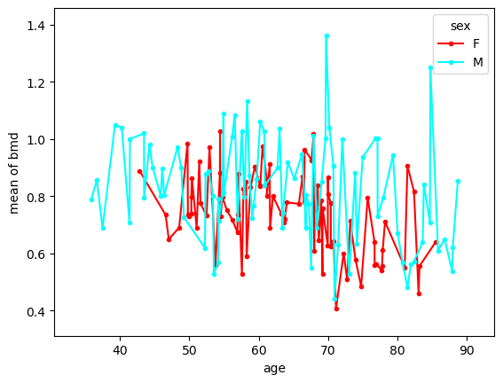

```python
from statsmodels.graphics.factorplots import interaction_plot
df = pd.read_csv('data/bmd_prep.csv')
fig = interaction_plot(x=df['age'], trace=df['sex'], response=df['bmd'])
plt.show()
```

Średnie wartości wskaźnika `bmd` dla mężczyzn są na ogół większe niż u kobiet. W wieku ok. 50 lat można jednak zauważyć, że kobiety mają średnio większy ten wskaźnik. Wśród mężczyzn możemy zaobserwować wartości odstające - 2 piki ilustrujące wyjątkowo wysokie średnie wartości wskaźnika `bmd`. U kobiet można zauważyć, że wraz z wiekiem osiągane są coraz niższe wartości średniej `bmd`.

#### 6. Macierz korelacji

```python
df[numeric_vars].corr()
```

|  | age | weight_kg | bmd |
| --- | --- | --- | --- |
| age | 1.000000 | -0.093117 | -0.306576 |
| weight_kg | -0.093117 | 1.000000 | 0.555964 |
| bmd | -0.306576 | 0.555964 | 1.000000 |

Najsilniejszą korelację obserwujemy dla zmiennych `bmd` oraz `weight_kg` (wsp. korelacji równy **0.56**). Występuje również umiarkowany związek (liniowy) między parami zmiennych `bmd` oraz `age` (**-0.31**). Natomiast korelacja między zmiennymi niezależnymi (`age` oraz `weight_kg`) jest słaba (**-0.1**)

#### 7. Test Chi kwadrat

Chi^2 Test Results. Variable: bmd

|  | variable | Chi^2 | p_value |
| --- | --- | --- | --- |
| 0 | age | 27885.000000 | 0.241274 |
| 1 | sex | 164.998739 | 0.485386 |
| 2 | fracture | 169.000000 | 0.399333 |
| 3 | weight_kg | 8520.316071 | 0.207943 |
| 4 | height_cm | 8419.016667 | 0.485603 |
| 5 | medication | 338.000000 | 0.368880 |
| 6 | waiting_time | 7606.408333 | 0.444926 |

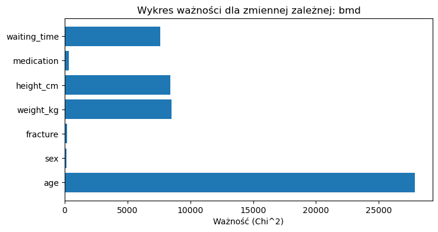

```python
from scipy.stats import chi2_contingency
df = pd.read_csv('data/bmd_prep.csv')

dependent_var = 'bmd'

X = df
y = X[dependent_var]
X = X.drop(columns=[dependent_var])

chi2_test_df = pd.DataFrame(columns=['variable', 'Chi^2', 'p_value'])
chi2_test_results = []
# perform chi2 test for each independent variable
for column in X.columns:
    data_cont = pd.crosstab(X[column], y)
    chi2, p_value, _, _ = chi2_contingency(data_cont)
    chi2_test_results.append({'variable': column,'Chi^2': chi2, 'p_value': p_value})
chi2_test_df = chi2_test_df.from_records(chi2_test_results)

s = chi2_test_df.style.set_caption(f'Chi^2 Test Results. Variable: {dependent_var}')
# Plot variable importance diagram
plt.figure(figsize=(8,4))
plt.barh(chi2_test_df['variable'], chi2_test_df['Chi^2'])
plt.xlabel('Ważność (Chi^2)')
plt.title(f'Wykres ważności dla zmiennej zależnej: {dependent_var}')
display(s)
```

Z przeprowadzonego testu Chi^2 wynika, iż najważniejszymi zmiennymi objaśniającymi dla zmiennej `bmd` są `age`, `weight_kg` i `height`. Natomiast wybrana jako predyktor zmienna `sex` okazuje się być nie tak ważna.

#### 8. Wykresy ramka-wąsy dla zmiennych ilościowych

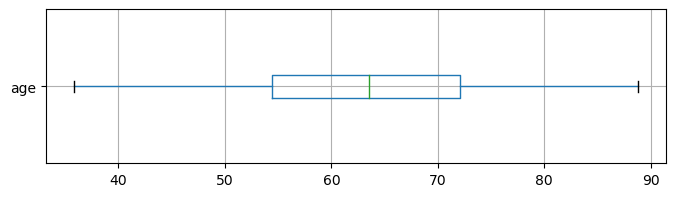

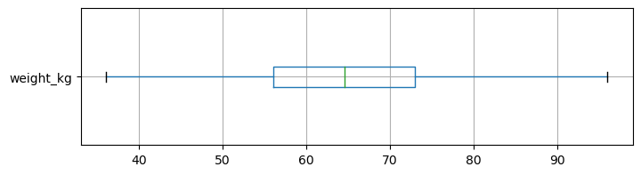

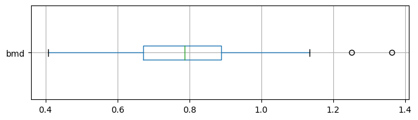

```python
for var in numeric_vars:
    fig = df.boxplot(column=var, vert=False, figsize=(8,2))
    plt.figure(figsize=(8,2))
```

Wykresy ramka-wąsy skategoryzowane względem płci

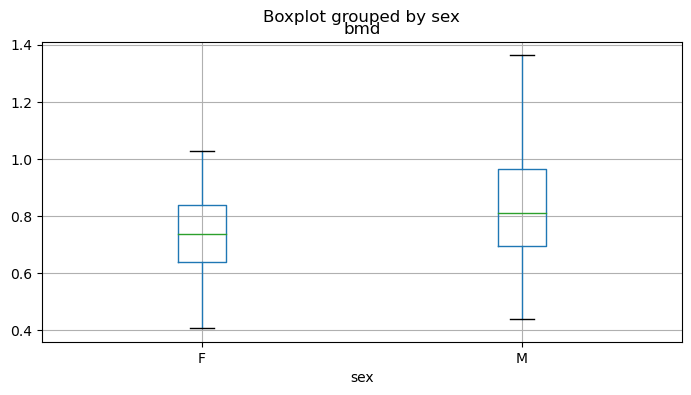

```python
df.boxplot(column='bmd', by='sex', figsize=(8,4))
```

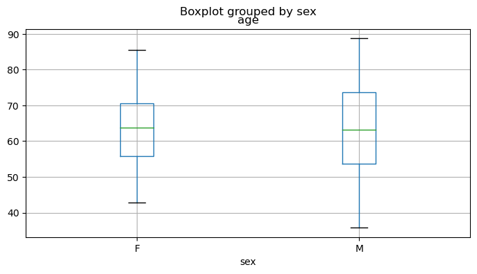

```python
df.boxplot(column='age', by='sex', figsize=(8,4))
```

Zarówno dla `bmd` jak i dla `age` obserwujemy, że ich wartości cechują się mniejszym rozrzutem w przypadku kobiet niż u mężczyzn.

#### 9. Test normalny dla zmiennych

```python
from scipy.stats import normaltest

features = ['age', 'weight_kg', 'bmd']
for feature in features:
    alpha = 0.05
    p_value = normaltest(df[feature])[1]
    if(p_value < alpha):
        print(f'Zmienna {feature} NIE POCHODZI z rozkładu normalnego. P-value:', p_value)
    else:
        print(f'Zmienna {feature} POCHODZI z rozkładu normalnego. P-value:', p_value)
```

```
Zmienna age NIE POCHODZI z rozkładu normalnego. P-value: 0.03202778072330057
Zmienna weight_kg POCHODZI z rozkładu normalnego. P-value: 0.8899086011365848
Zmienna bmd POCHODZI z rozkładu normalnego. P-value: 0.2986369345960301
```

Zmienne `bmd` oraz `weight_kg` cechują się rozkładem normalnym. Wartośc p dla tych zmiennych jest większa niż założony poziom istotności alfa = 0.05.

#### 10. Wykresy rozrzutu dla skorelowanych zmiennych

```
Regression equation: y = 0.26 + 0.01x
```

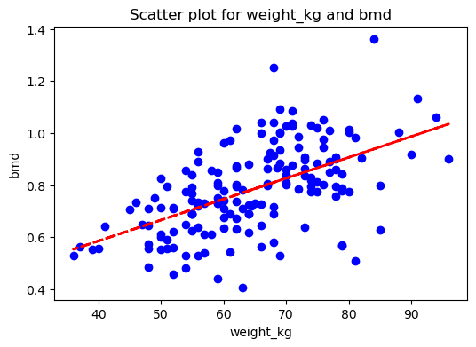

```python
x=df['weight_kg']
y=df['bmd']

def custom_scatter(x, y):
    #find line of best fit
    a, b = np.polyfit(x, y, 1)
    #add points to plot
    plt.figure(figsize=(6,4))
    plt.scatter(x, y, color='blue')
    #add line of best fit to plot
    plt.plot(x, a*x+b, color='red', linestyle='--', linewidth=2)
    plt.xlabel(x.name)
    plt.ylabel(y.name)
    plt.title(f'Scatter plot for {x.name} and {y.name}')
    print('Regression equation:', 'y = ' + '{:.2f}'.format(b) + ' + {:.2f}'.format(a) + 'x')

custom_scatter(x, y)
```

```
Regression equation: y = 1.05 + -0.00x
```

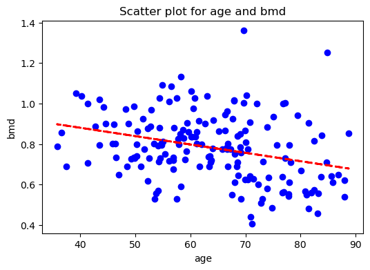

```python
x=df['age']
y=df['bmd']

custom_scatter(x, y)
```

Wykresy rozrzutu skategoryzowane względem płci

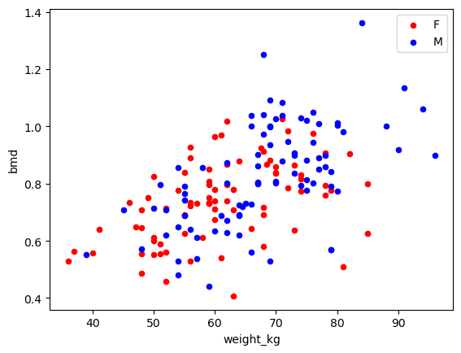

```python
x='weight_kg'
y='bmd'

def scatter_by_sex(x, y):
    fig, ax = plt.subplots()
    colors = {'F':'red', 'M':'blue'}

    grouped = df.groupby('sex')
    for key, group in grouped:
        group.plot(ax=ax, kind='scatter', x=x, y=y, label=key, color=colors[key], marker='o')

    plt.show()

scatter_by_sex(x, y)
```

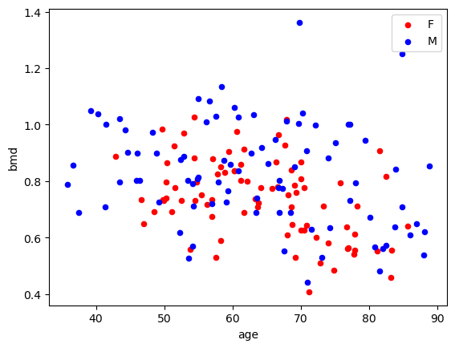

```python
x='age'
y='bmd'

scatter_by_sex(x, y)
```

Obserwujemy więcej wartości odstających w przypadku mężczyzn.

#### 11. Opracowanie wyników i wnioski

- Zmienne `age` oraz `weight_kg` są skorelowane ze zmienną zależną `bmd`. Współczynnik korelacji liniowej wynosi dla `age`: **-0.31** (umiarkowana korelacja) oraz dla `weight_kg`: **0.56** (silna korelacja).
- Najsilniejszy wpływ ma zmienna `weight_kg`. Otrzymana na wykresie rozrzutu prosta regresji cechuje się największym nachyleniem prostej względem osi poziomej. Możemy zaobserwować pewną zależność liniową między tymi zmiennymi.
- Zmienne objaśniające (`age` oraz `weight_kg`) nie są wzajemnie skorelowane. Korelacja między tymi predyktorami jest słaba (wsp. kor. wynosi ok. 0.1).

### Indukcja drzew decyzyjnych - drzewo regresyjne dla zmiennej `bmd`

```python
# Potrzebne biblioteki do indukcji drzew regresyjnych
import pandas as pd
from sklearn.tree import DecisionTreeRegressor, plot_tree
from sklearn.model_selection import train_test_split, cross_val_score
from sklearn.metrics import r2_score
import matplotlib.pyplot as plt
```

Przygotowanie zbioru danych - podział na uczący i testowy

```python
df = pd.read_csv('data/bmd_prep.csv')

target_var = 'bmd'
vars_to_exclude = ['medication', 'fracture']

X = df.drop(columns=[target_var]+vars_to_exclude)
y = df[target_var]

# Encode categorical data
X = pd.get_dummies(X)

# Split data to training and testing set
X_train, X_test, y_train, y_test = train_test_split(X, y, test_size=0.25, random_state=0)
X_train.head()
```

|  | age | weight_kg | height_cm | waiting_time | sex_F | sex_M |
| --- | --- | --- | --- | --- | --- | --- |
| 16 | 57.934593 | 67.0 | 160.0 | 5 | 0 | 1 |
| 66 | 84.787394 | 68.0 | 165.0 | 11 | 0 | 1 |
| 136 | 68.017748 | 58.0 | 153.0 | 8 | 1 | 0 |
| 40 | 73.230427 | 52.0 | 153.0 | 89 | 1 | 0 |
| 160 | 84.721764 | 52.0 | 161.0 | 32 | 0 | 1 |

### 1. Utworzenie drzewa regresyjnego

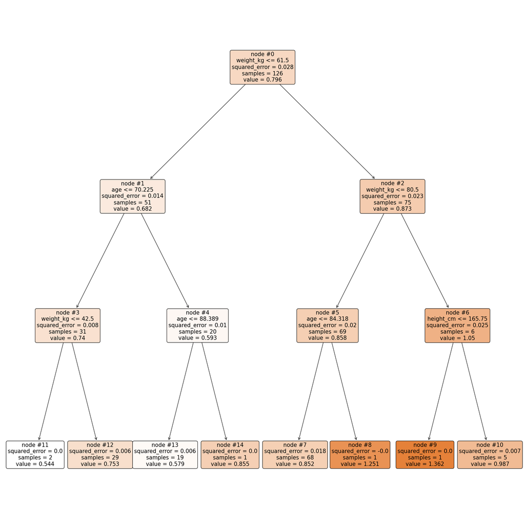

```python
params = {
    'max_depth': 3,
    'min_samples_split': 5,
    'max_leaf_nodes': 10
}

tree = DecisionTreeRegressor(**params)

# Fits the decision tree to training data
tree.fit(X_train, y_train)

fig = plt.figure(figsize=(25, 25))

# Creates a visual display of the model.
# Keep max_depth small for better visualization
t = plot_tree(
    tree,
    node_ids=True,
    feature_names=X.columns,
    rounded=True,
    filled=True)
```

### 2. Ważność predyktorów

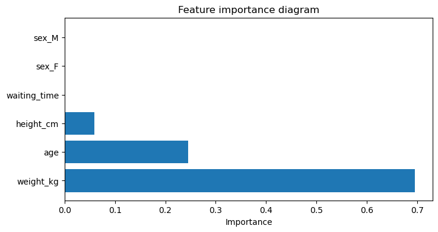

```python
features = X.columns.tolist()

importances_sk = tree.feature_importances_

feature_importance = []
for i, feature in enumerate(features):
    feature_importance.append({'feature': feature,'importance': round(importances_sk[i], 3)})
# sort features by their importance
feature_importance = sorted(feature_importance, key=lambda d: d['importance'], reverse=True)

feature_importance_df = pd.DataFrame(columns=['feature', 'importance'])
feature_importance_df = feature_importance_df.from_records(feature_importance)

plt.figure(figsize=(8,4))
plt.barh(feature_importance_df['feature'], feature_importance_df['importance'])
plt.xlabel('Importance')
plt.title(f'Feature importance diagram')
```

Najważniejszymi predyktorami w otrzymanym drzewie są `weight_kg`, `age` oraz `height_cm`. Użyta w hipotezie zmienna `sex` wg. otrzymanego drzewa jest nieważna.

##### 1. Reguła dla węzła #13:

- Jeśli osoba waży mniej niż 61.5 kg, a jej wiek znajduje się w przedziale od 70 do 89, wskaźnik `bmd` takiej osoby będzie niski i średnio wynosił 0.579
- Wariancja: 0.006
- Średnia: 0.579

##### 3. Reguła dla węzła #7:

- Jeśli waga osoby wynosi od 61.5 do 80 kg, a jej wiek jest mniejszy niż 84 lata, wskaźnik `bmd` takiej osoby będzie średnio wynosił 0.852 (dobra wartość)
- Wariancja: 0.018
- Średnia: 0.852

### 5. Koszt resubstytucji, współczynnik determinacji drzewa

```python
# Calculate the R-squared value
y_pred = tree.predict(X)
r2 = r2_score(y, y_pred)
RSS = sum((y - y_pred)**2)
cv_score = cross_val_score(tree, X, y, cv=5, scoring='neg_mean_squared_error')
print(f"Koszt resubstytucji (RSS): {RSS:.3f}")
print(f"Współczynnik determinacji (R^2): {r2:.3f}")
```

```
Koszt resubstytucji (RSS): 4.065
Współczynnik determinacji (R^2): 0.127
```

Otrzymana wartośc współczynnika determinacji jest niska (Rmax = 1). Oznacza, to że jakość modelu (drzewa) nie jest dobra

### Wybrany algorytm data mining - KNN

```python
# Niezbędne biblioteki
import matplotlib.pyplot as plt
import numpy as np
import pandas as pd
from sklearn.model_selection import GridSearchCV
from sklearn.neighbors import KNeighborsRegressor
from sklearn.preprocessing import MinMaxScaler
from sklearn.model_selection import train_test_split
```

#### 1. Przygotowanie danych i wybór zmiennych

```python
df = pd.read_csv('data/bmd_prep.csv')

all_num_predictors = df.select_dtypes(include=np.number).columns.tolist()
# normalization of numeric variables
df[all_num_predictors] = MinMaxScaler().fit_transform(df[all_num_predictors])

target_var = 'bmd'
num_predictors = ['age', 'weight_kg', 'waiting_time']
cat_predictors =  ['sex']

X = df[num_predictors + cat_predictors]
y = df[target_var]

# one-hot encode categorical variables
X = pd.get_dummies(X)

# Split data to training and testing set
X_train, X_test, y_train, y_test = train_test_split(X, y, test_size=0.25, random_state=0)
X_train.head()
```

|  | age | weight_kg | waiting_time | sex_F | sex_M |
| --- | --- | --- | --- | --- | --- |
| 16 | 0.417844 | 0.516667 | 0.000000 | 0 | 1 |
| 66 | 0.925077 | 0.533333 | 0.065934 | 0 | 1 |
| 136 | 0.608308 | 0.366667 | 0.032967 | 1 | 0 |
| 40 | 0.706773 | 0.266667 | 0.923077 | 1 | 0 |
| 160 | 0.923837 | 0.266667 | 0.296703 | 0 | 1 |

#### 2. Optymalizacja wartości k - V-krotny sprawdzian krzyżowy

```python
# Sets up the kNN regressor object
knn = KNeighborsRegressor()

# Search parameters
param = range(3, 15, 2)

# Sets up GridSearchCV object and stores it in grid variable
grid = GridSearchCV(
    knn,
    {'n_neighbors': param})

# Fits the grid object and gets the best model
best_knn = grid \
    .fit(X, y) \
    .best_estimator_

# Displays the optimum model
best_knn.get_params()
```

```
{'algorithm': 'auto',
 'leaf_size': 30,
 'metric': 'minkowski',
 'metric_params': None,
 'n_jobs': None,
 'n_neighbors': 5,
 'p': 2,
 'weights': 'uniform'}
```

##### Wykres wyniku sprawdzianu krzyżowego w zależności od ilości sąsiadów

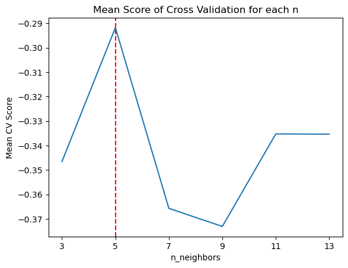

```python
# Plots mean_test_scores vs. total neighbors
plt.plot(
    param,
    grid.cv_results_['mean_test_score'])

# Adds labels to the plot
plt.xticks(param)
plt.ylabel('Mean CV Score')
plt.xlabel('n_neighbors')
plt.title('Mean Score of Cross Validation for each n')

# Draws a vertical line where the best model is
plt.axvline(
    x=best_knn.n_neighbors,
    color='red',
    ls='--')
```

Przeprowadzony sprawdzian krzyżowy wykazał, że najbardziej optymalną ilością sąsiadów jest `5`

#### 3. Algorytm KNN dla optymalnych parametrów

```python
params = best_knn.get_params()
knn = KNeighborsRegressor(**params)
knn.fit(X, y)
```

```
KNeighborsRegressor()
```

#### Dokładność otrzymanego modelu

```python
print(
    'Accuracy on training data: '
    + str("{:.2%}".format(knn.score(X_train, y_train))))
print(
    'Accuracy on testing data: '
    + str("{:.2%}".format(knn.score(X_test, y_test))))
```

```
Accuracy on training data: 57.72%
Accuracy on testing data: 55.54%
```

#### 4. Interpretacja wyników

Otrzymana dokładność modelu nie jest ogólnie zadowalająca. Biorąc pod uwagę, że rozkład punktów w zbiorze danych stanowi tak naprawdę jedną wielką chmurę punktów (co jest widoczne na wykresach rozrzutu), KNN wbrew pozorom poradził sobie nienajgorzej. Na podstawie wybranych zmiennych objaśniających, model jest w stanie poprawnie przewidzieć wartość wskaźnika `bmd` z dokładnością nieco ponad `50%`.

## **Hipoteza 2** - badanie zależności rodzaju leczenia, wieku oraz wartości wskaźnika `bmd` na wystąpienie złamania

### Badanie struktury populacji

```python
# Potrzebne biblioteki
import numpy as np
import matplotlib.pyplot as plt
```

#### 1. Statystyki opisowe - zmienne ilościowe

```python
numeric_vars = ['age', 'bmd']
np.round(df[numeric_vars].describe(),3)
```

[output not shown]

Najstarsza osoba w zbiorze ma niemal 89 lat natomiast najmłodsza niecałe 36. Waga pacjentów mieści się w zakresie od 36 do 96 kg. Średnia wartość wskaźnika `bmd` wynosi 0.783 a mediana 0.786.

wariancja

```python
np.round(df[numeric_vars].var(), 3)
```

```
age    152.694
bmd      0.028
dtype: float64
```

moda

```python
np.round(df[numeric_vars].mode(), 3)
```

|  | age | bmd |
| --- | --- | --- |
| 0 | 35.814 | 0.690 |
| 1 | 36.648 | 0.713 |
| 2 | 37.462 | 0.889 |
| 3 | 39.255 | NaN |
| 4 | 40.232 | NaN |
| ... | ... | ... |
| 164 | 85.902 | NaN |
| 165 | 86.860 | NaN |
| 166 | 87.935 | NaN |
| 167 | 88.024 | NaN |
| 168 | 88.754 | NaN |

169 rows × 2 columns

Najczęsciej występujące w zbiorze wartości `bmd` to 0.69, 0.713 oraz 0.889.

#### 2. Tabele liczności - zmienne jakościowe

```python
categorical_vars = ['medication', 'fracture']
df[categorical_vars].value_counts()
```

```
medication       fracture
No medication    no fracture    95
                 fracture       41
Glucocorticoids  no fracture    19
Anticonvulsant   no fracture     5
Glucocorticoids  fracture        5
Anticonvulsant   fracture        4
dtype: int64
```

Większośc osób w badanej próbie stanowią osoby zdrowe - bez złamania oraz nieleczone. Drugą najliczniejszą grupę stanowią osoby, które doznały złamania i nie były leczone. Pozostałe osoby są to osoby leczone.

```python
for var in categorical_vars:
    ft = df[[var]].value_counts()
    display(ft)
```

```
medication
No medication      136
Glucocorticoids     24
Anticonvulsant       9
dtype: int64
```

```
fracture
no fracture    119
fracture        50
dtype: int64
```

Pod względem zmiennej `fracture` mamy dość nierównomierny rozkład - ponad 2/3 wszystkich osób stanowią osoby, które nie doznały złamania. Niewielka część całej próby stanowią osoby leczone - ok 20% (33/169 * 100%)

### 3. Tabela wielodzielcza

Tabela składać się będzie z dwóch części - pierwsza z nich dotyczy osób, które nie doznały złamania (`no fracture`), a druga, które doznały złamania (`fracture`)

```python
# group values in numeric features to equal ranges
df = pd.read_csv('data/bmd_prep.csv')
df['age'] = pd.cut(df['age'], 6, precision=0)

# create pivot tables for unique values in 'fracture' column
fracture_distinct_values = df['fracture'].unique().tolist()
for value in fracture_distinct_values:
    pivot = df[df.fracture == value].pivot_table(values='fracture',
                    index=['medication', ],
                    columns=['age'],
                    aggfunc=['count'],
                    margins=True,
                    margins_name='Checksum',
                    fill_value='-')
    print(f'Pivot table for: "{value}"')
    display(pivot)
```

```
Pivot table for: "no fracture"
```

| age medication | count (36.0, 45.0] | count (45.0, 53.0] | count (53.0, 62.0] | count (62.0, 71.0] | count (71.0, 80.0] | count (80.0, 89.0] | count Checksum |
| --- | --- | --- | --- | --- | --- | --- | --- |
| Anticonvulsant | 0 | 0 | 4 | 1 | 0 | 0 | 5 |
| Glucocorticoids | 1 | 3 | 6 | 5 | 3 | 1 | 19 |
| No medication | 8 | 17 | 27 | 28 | 11 | 4 | 95 |
| Checksum | 9 | 20 | 37 | 34 | 14 | 5 | 119 |

```
Pivot table for: "fracture"
```

| age medication | count (36.0, 45.0] | count (45.0, 53.0] | count (53.0, 62.0] | count (62.0, 71.0] | count (71.0, 80.0] | count (80.0, 89.0] | count Checksum |
| --- | --- | --- | --- | --- | --- | --- | --- |
| Anticonvulsant | 0 | 1 | 0 | 0 | 0 | 3 | 4 |
| Glucocorticoids | 0 | 0 | 1 | 0 | 2 | 2 | 5 |
| No medication | 2 | 4 | 6 | 10 | 9 | 10 | 41 |
| Checksum | 2 | 5 | 7 | 10 | 11 | 15 | 50 |

Na podstawie otrzymanych tabel dla zmiennej `fracture` możemy zaobserwować, że najwięcej przypadków osób ze złamaniem w badanej próbie to osoby w przedziale wiekowymi od 60 do 90 lat (osoby starsze). Zdecydowana większość osób w tej próbie nie miała leczenia. Większośc osób, które nie doznały złamania to osoby w wieku od 45 do 70 lat. Niewielka częśc osób miała podany lek przeciwdrgawkowy (anticonvulsant) lub glikokortykoidy, przy czym tylko kilka osób, które miały podane te leki, doznały złamania (4+5 = 9).

### 4. Histogram dla zmiennej `fracture` skategoryzowany względem rodzaju leczenia (`medication`)

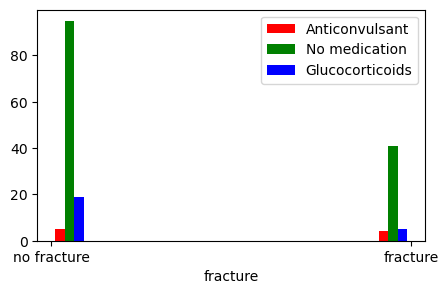

```python
df = pd.read_csv('data/bmd_prep.csv')
var = 'fracture'
grouping_var = 'medication'

medication_labels = df['medication'].unique().tolist()

anticonv = df.loc[df[grouping_var]==medication_labels[0], var]
gluco = df.loc[df[grouping_var]==medication_labels[1], var]
no_med = df.loc[df[grouping_var]==medication_labels[2], var]

plt.figure(figsize=(5,3))
plt.hist([anticonv, gluco, no_med], label=medication_labels, color=['red', 'green', 'blue'])
plt.legend(loc='upper right')
plt.xlabel(var)
plt.show()
```

### 5. Wykres interakcji (wykres średnich `bmd` w zależności od złamania oraz rodzaju leczenia)

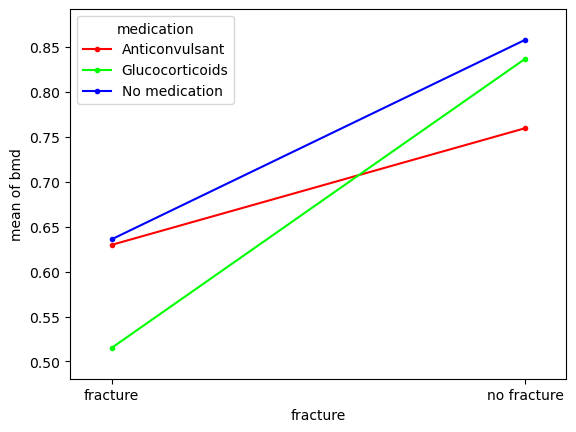

```python
from statsmodels.graphics.factorplots import interaction_plot

df = pd.read_csv('data/bmd_prep.csv')
fig = interaction_plot(x=df['fracture'], trace=df['medication'], response=df['bmd'])
plt.show()
```

Spostrzeżenia:

- Średnia wartość `bmd` w przypadku osób nieleczonych jest najwyższa sposród wszystkich metod leczenia.
- Bardzo niska średnia wartość `bmd` jest w przypadku osób leczonych przy pomocy glukokortykozy. Można wnioskować, że leki te stosowane są często przy naprawdę słabym stanie kości.

### 6. Macierz korelacji

```python
df = pd.read_csv('data/bmd_prep.csv')
numeric_vars = ['bmd', 'age']
df[numeric_vars].corr()
```

|  | bmd | age |
| --- | --- | --- |
| bmd | 1.000000 | -0.306576 |
| age | -0.306576 | 1.000000 |

Jedynymi zmiennymi ilościowymi w badanej hipotezie są zmienne opisujące `age` oraz `bmd`. Korelacja między nimi jest umiarkowana. Ponieważ zmienna zależna jest jakościowa, nie da się dla niej policzyć współczynnika korelacji

### 7. Test Chi kwadrat

Chi^2 Test Results. Variable: fracture

|  | variable | Chi^2 | p_value |
| --- | --- | --- | --- |
| 0 | age | 169.000000 | 0.463822 |
| 1 | sex | 0.000000 | 1.000000 |
| 2 | weight_kg | 54.281698 | 0.350510 |
| 3 | height_cm | 40.926944 | 0.842458 |
| 4 | medication | 1.856893 | 0.395167 |
| 5 | waiting_time | 51.552251 | 0.265660 |
| 6 | bmd | 169.000000 | 0.399333 |

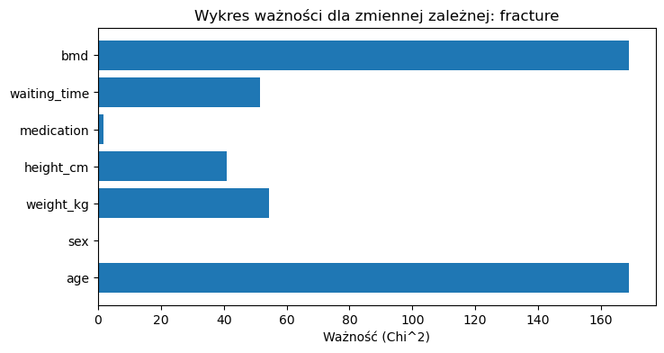

```python
from scipy.stats import chi2_contingency
df = pd.read_csv('data/bmd_prep.csv')

dependent_var = 'fracture'

X = df
y = X[dependent_var]
X = X.drop(columns=[dependent_var])

chi2_test_df = pd.DataFrame(columns=['variable', 'Chi^2', 'p_value'])
chi2_test_results = []
# perform chi2 test for each independent variable
for column in X.columns:
    data_cont = pd.crosstab(X[column], y)
    chi2, p_value, _, _ = chi2_contingency(data_cont)
    chi2_test_results.append({'variable': column,'Chi^2': chi2, 'p_value': p_value})
chi2_test_df = chi2_test_df.from_records(chi2_test_results)

s = chi2_test_df.style.set_caption(f'Chi^2 Test Results. Variable: {dependent_var}')
# Plot variable importance diagram
plt.figure(figsize=(8,4))
plt.barh(chi2_test_df['variable'], chi2_test_df['Chi^2'])
plt.xlabel('Ważność (Chi^2)')
plt.title(f'Wykres ważności dla zmiennej zależnej: {dependent_var}')
display(s)
```

Dla zmiennej `fracture` najważniejszymi predyktorami okazały się `age` oraz `bmd`, które zostały wybrane przy definiowaniu hipotezy. Natomiast zmienna `medication` okazała się bardzo mało ważna.

### 8. Wykresy ramka-wąsy

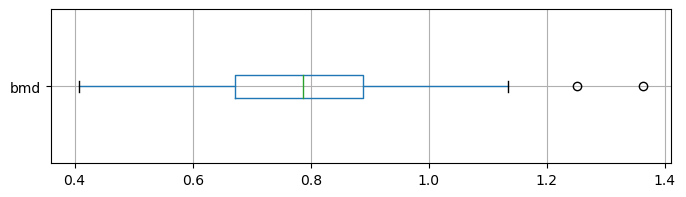

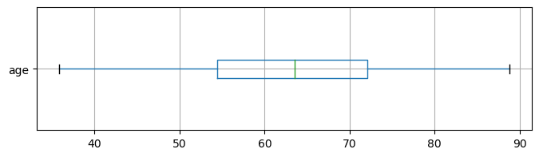

```python
for var in numeric_vars:
    fig = df.boxplot(column=var, vert=False, figsize=(8,2))
    plt.figure(figsize=(8,2))
```

Skategoryzowane wykresy ramka wąsy względem zmiennej `fracture`

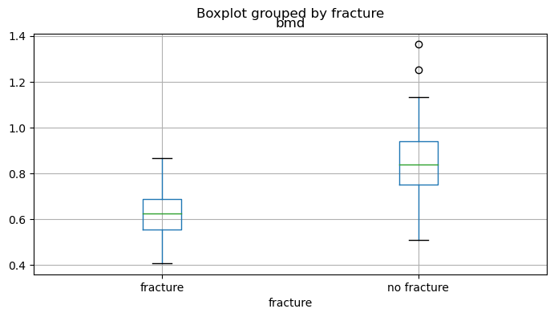

```python
df.boxplot(column='bmd', by='fracture', figsize=(8,4))
```

Osoby, które doznały złamania cechują się na ogół niższą wartością `bmd` oraz mniejszym rozstępem tych wartości. W przypadku osób które nie doznały złamania, cechuje ich większy rozstęp wartości `bmd`, wartość mediany oraz średniej. Zdarzyły się nawet 2 przypadki odstające, u których kości mają wyjątkowo dużo minerałów (wysokie `bmd`).

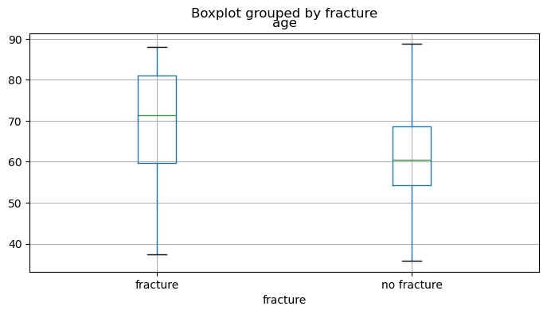

```python
df.boxplot(column='age', by='fracture', figsize=(8,4))
```

Na ogół osoby, które doznały złamania są średnio starsze niż osoby bez złamania. Rozkład osób, które nie doznały złamania bardziej rozłożony i przypomina rozkład normalny.

### 9. Test normalny

```python
from scipy.stats import normaltest

features = ['age', 'bmd']
for feature in features:
    alpha = 0.05
    p_value = normaltest(df[feature])[1]
    if(p_value < alpha):
        print(f'Zmienna {feature} NIE POCHODZI z rozkładu normalnego. P-value:', p_value)
    else:
        print(f'Zmienna {feature} POCHODZI z rozkładu normalnego. P-value:', p_value)
```

```
Zmienna age NIE POCHODZI z rozkładu normalnego. P-value: 0.03202778072330057
Zmienna bmd POCHODZI z rozkładu normalnego. P-value: 0.2986369345960301
```

Spośród zmiennych użytych do badania słuszności hipotezy 2, tylko zmienna `bmd` cechuje się rozkładem normalnym, zakładając poziom istotności alfa = `0.05`.

### 10. Wykresy rozrzutu

Ponieważ zmienna zależna nie jest zmienną ilościową, nie da się dla niej wygenerować wykresu rozrzutu. Jednak można wykonać wykres rozrzutu dla zmiennych opisujących `bmd` oraz `age` skategoryzowany względem zmiennej zależnej `fracture`.

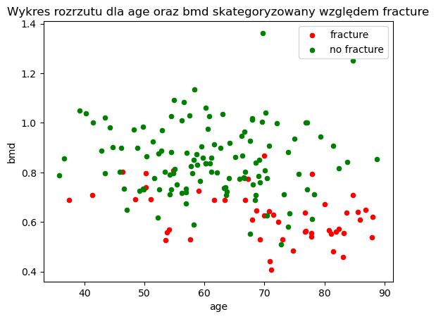

```python
x='age'
y='bmd'

fig, ax = plt.subplots()
colors = {'fracture':'red', 'no fracture':'green'}

grouped = df.groupby('fracture')
for key, group in grouped:
    group.plot(ax=ax, kind='scatter', x=x, y=y, label=key, color=colors[key], marker='o')

plt.title(f'Wykres rozrzutu dla {x} oraz {y} skategoryzowany względem fracture')
plt.show()
```

Obserwacje:

- Znaczna część przypadków, gdzie doszło do złamania występuje dla wartości wskaźnika `bmd` mniejszego niż ok. 0.7
- Przesuwając się na prawo wzdłuż osi poziomej - im większy wiek tym więcej przypadków złamania.

### 11. Opracowanie wyników i wnioski

- Dla tej hipotezy nie można określić korelacji między predyktorami a zmienną zależną, gdyż jest ona jakościowa.
- Występuje umiarkowana korelacja między predyktorami `age` oraz `bmd` (wsp. kor. = -0.31.).
- Widzimy wyraźny związek między zmienną `fracture` a predyktorami `bmd` oraz `age`. Można pokusić się o stwierdzenie, że im starsza dana osoba i im mniej minerałów zawierają kości tej osoby, tym większa szansa, że osoba dozna złamania.
- W przypadku zmiennej `medication` relacja ta nie jest tak oczywista. Stosunek osób, które doznały złamania do osób bez złamania, gdzie każda z nich była leczona przy pomocy glikokortykoidów wynosi 5:19. Zatem ok. 80% osób, które były leczone przy pomocy glukokortykozy nie doznały złamania - możliwe że ten lek jest skuteczny w leczeniu niedoboru minerału w kościach i pozwala zapobiec złamaniom

### Indukcja drzew decyzyjnych - drzewo klasyfikacyjne dla zmiennej `fracture`

```python
# Niezbędne biblioteki do drzew klasyfikacyjnych
import pandas as pd
from sklearn.tree import DecisionTreeClassifier, plot_tree
from sklearn.metrics import confusion_matrix, ConfusionMatrixDisplay
from sklearn.model_selection import train_test_split
import matplotlib.pyplot as plt
```

#### Przygotowanie danych do modelu

```python
df = pd.read_csv('data/bmd_prep.csv')

target_var = 'fracture'
# features to exclude from model
vars_to_exclude = ['sex', 'waiting_time', 'weight_kg']

y = df[target_var]
X = df.drop(columns=[target_var]+vars_to_exclude)

fracture_labels = ['no fracture', 'fracture']
medication_labels = ['No medication', 'Glucocorticoids', 'Anticonvulsant']
# Treat two medication methods as one
X['medication'] = X['medication'].replace(medication_labels, [0, 1, 1])
y = y.replace(fracture_labels, [0, 1])

# Split data to training and testing set
X_train, X_test, y_train, y_test = train_test_split(X, y, test_size=0.25, random_state=0)
X_train.head()
```

|  | age | height_cm | medication | bmd |
| --- | --- | --- | --- | --- |
| 16 | 57.934593 | 160.0 | 1 | 0.7978 |
| 66 | 84.787394 | 165.0 | 0 | 1.2508 |
| 136 | 68.017748 | 153.0 | 0 | 0.6103 |
| 40 | 73.230427 | 153.0 | 0 | 0.7128 |
| 160 | 84.721764 | 161.0 | 0 | 0.7085 |

Do modelu została uwzględniona zmienna `height_cm` ze względu na większą dokładność otrzymywanego modelu

### 1. Utworzenie drzewa klasyfikacyjnego

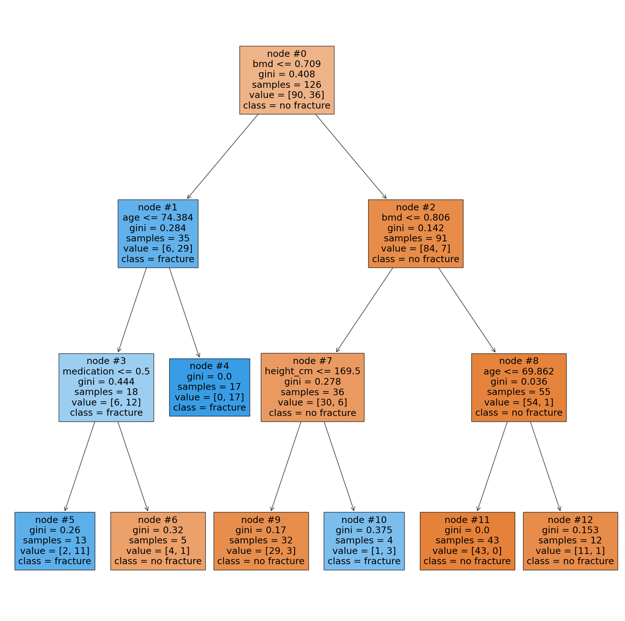

```python
params = {
    'max_depth': 3,
    'min_samples_split': 5,
    'max_leaf_nodes': 10
}
tree = DecisionTreeClassifier(**params)

# Fits the decision tree to training data
tree.fit(X_train, y_train)

fig = plt.figure(figsize=(25, 25))

# Creates a visual display of the model.
# Keep max_depth small for better visualization
t = plot_tree(
    tree,
    feature_names=X.columns,
    class_names=fracture_labels,
    node_ids=True,
    filled=True)
```

### 2. Ważność predyktorów

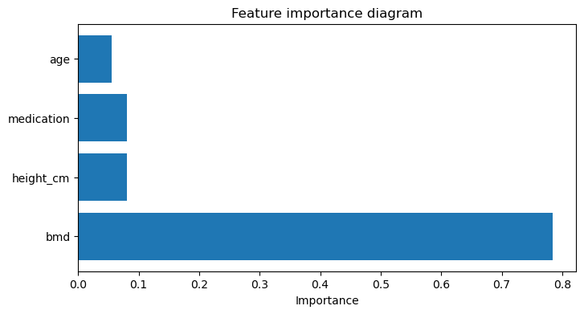

```python
features = X.columns.tolist()

importances_sk = tree.feature_importances_

feature_importance = []
for i, feature in enumerate(features):
    feature_importance.append({'feature': feature,'importance': round(importances_sk[i], 3)})
# sort features by their importance
feature_importance = sorted(feature_importance, key=lambda d: d['importance'], reverse=True)

feature_importance_df = pd.DataFrame(columns=['feature', 'importance'])
feature_importance_df = feature_importance_df.from_records(feature_importance)

plt.figure(figsize=(8,4))
plt.barh(feature_importance_df['feature'], feature_importance_df['importance'])
plt.xlabel('Importance')
plt.title(f'Feature importance diagram')
```

Najważniejszą zmienną objaśniającą w otrzymanym modelu jest wskaźnik `bmd`. Pozostałe zmienne wykorzystane w modelu są mniej ważne

### 3. Reguły dla najbardziej wyrazistych klas

##### 1. Reguła dla węzła #5 - Jeśli wskaźnik `bmd` jest mniejszy bądź równy 0.709, wiek mniejszy niż 74 lata oraz pacjent nie był leczony, istnieje niemal 85% szansy, że osoba ta dozna złamania

- Pewność reguły: 11/13 * 100% = `84.5%`
- Wsparcie reguły: 13/126 * 100% = `10.3%`

##### 3. Reguła dla węzła #9 - Jeśli wskaźnik `bmd` osoby jest w przedziale (0.709, 0.806], a jej wzrost jest mniejszy bądź równy 169.5 cm, jest 90% szansy, że osoba ta nie doznała złamania

- Pewność reguły: 29/32 * 100% = `90.5%`
- Wsparcie reguły: 32/126 * 100% = `25.4%`

##### 4. Reguła dla węzła #8 - Jeśli wskaźnik `bmd` osoby jest większy niż 0.806, to jest ponad 98% szansy, że osoba ta nie doznała złamania.

- Pewność reguły: 54/55 * 100% = `98.2%`
- Wsparcie reguły: 55/126 * 100% = `43.6%`

### 4. Macierz klasyfikacji

```
<sklearn.metrics._plot.confusion_matrix.ConfusionMatrixDisplay at 0x17f59a8d9a0>
```

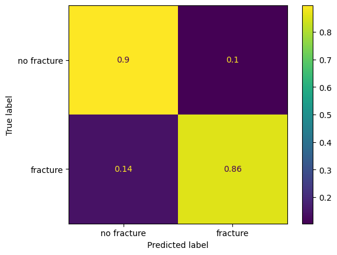

```python
predictions = tree.predict(X_test)
cm = confusion_matrix(y_test, predictions, labels=tree.classes_, normalize='true')
disp = ConfusionMatrixDisplay(confusion_matrix=cm, display_labels=fracture_labels)
disp.plot()
```

Wygenerowane drzewo przewiduje poprawnie brak złamania z `90%` dokładnością (True Negative) oraz jego obecność z dokładnością `86%` (True Positive)

##### Całkowity błąd drzewa

```python
print(
    'Accuracy on training data: '
    + str("{:.2%}".format(tree.score(X_train, y_train))))

print(
    'Accuracy on testing data: '
    + str("{:.2%}".format(tree.score(X_test, y_test))))
```

```
Accuracy on training data: 93.65%
Accuracy on testing data: 88.37%
```

Błąd drzewa w przypadku danych uczących wyniósł 100%-93.65% = `6.35%`, a dla zbioru testowego `11.63%`. Zatem jest to dość dokładny model

### 5. Weryfikacja hipotezy na podstawie drzewa

Na podstawie reguły 1 można stwierdzić, że osoby, które miały słabe kości (`bmd` niskie) oraz nie były leczone, istniała duża szansa, że osoba ta miała złamanie. Gdyby regułę zdefiniować dla sąsiedniego liścia, gdzie pacjenci byli leczeni istnieje duża szansa (4/5), że osoba ta nie doznała złamania. Zatem stwierdzenie, że leczenie wpływa na wystąpienie złamania zdefiniowane w ramach hipotezy jest słuszne.  
Porównując ze sobą reguły 2, 3 i 4 widzimy, że im wyższy wskaźnik `bmd` tym większa szansa, że osoba nie doznała złamania. Zatem stwierdzenie, że `bmd` wpływa na złamanie również jest uzasadnione.  
Wiek również ma (co prawda najmniejszy spośród wszystkich zmiennych) wpływ. Wg. reguły 2, osoby, które miały niski wskaźnik `bmd` oraz były w wieku powyżej 74 lat, doznały złamania ze 100% pewnością. Osoby młodsze niż 74 lata również doznały złamań ale szansa na to była mniejsza, gdy dodatkowo zostało zastosowane leczenie.  
Podsumowując, na podstawie wyników otrzymanych przy pomocy drzewa, hipotezę 2 można przyjąć. Każda ze zmiennych objaśniających ma większy lub mniejszy ale istotny wpływ na poprawne zaklasyfikowanie pacjenta pod względem wystąpienia złamania bądź nie.

### Wybrany algorytm data mining - Naiwny klasyfikator Bayesa

```python
# Niezbędne biblioteki
import matplotlib.pyplot as plt
import numpy as np
import pandas as pd
from sklearn.naive_bayes import GaussianNB
from sklearn.metrics import confusion_matrix, ConfusionMatrixDisplay
from sklearn.model_selection import train_test_split
```

#### 1. Przygotowanie zbioru danych i wybór zmiennych

```python
df = pd.read_csv('data/bmd_prep.csv')

target_var = 'fracture'

numeric_predictors = df.select_dtypes(include=np.number).columns.tolist()
categorical_predictors =  df.select_dtypes(exclude=np.number).columns.tolist()
# # exclude less important predictors
numeric_predictors.remove('height_cm')
numeric_predictors.remove('waiting_time')
# exclude target variable from training set
categorical_predictors.remove(target_var)

fracture_labels = ['no fracture', 'fracture']

X = df[numeric_predictors + categorical_predictors]
y = df[target_var]

# Encode categorical data
X_encoded = pd.get_dummies(X)
y_encoded = y.replace(fracture_labels, [0, 1])

# Split data to training and testing set
X_train, X_test, y_train, y_test = train_test_split(X_encoded, y_encoded, test_size=0.25, random_state=0)
X_train.head()
```

|  | age | weight_kg | bmd | sex_F | sex_M | medication_Anticonvulsant | medication_Glucocorticoids | medication_No medication |
| --- | --- | --- | --- | --- | --- | --- | --- | --- |
| 16 | 57.934593 | 67.0 | 0.7978 | 0 | 1 | 0 | 1 | 0 |
| 66 | 84.787394 | 68.0 | 1.2508 | 0 | 1 | 0 | 0 | 1 |
| 136 | 68.017748 | 58.0 | 0.6103 | 1 | 0 | 0 | 0 | 1 |
| 40 | 73.230427 | 52.0 | 0.7128 | 1 | 0 | 0 | 0 | 1 |
| 160 | 84.721764 | 52.0 | 0.7085 | 0 | 1 | 0 | 0 | 1 |

Dla wybranych wyżej zmiennych naiwny klasyfikator Bayesa osiągnął najmniejszą wartość błędu

#### 2. NaiveBayes - macierz klasyfikacji

```
<sklearn.metrics._plot.confusion_matrix.ConfusionMatrixDisplay at 0x24f0c2b5a60>
```

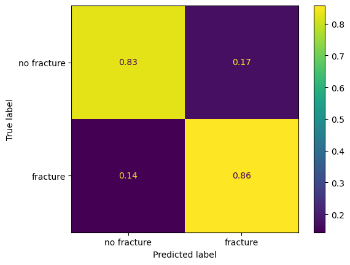

```python
# fit data to NaiveBayes object
nb = GaussianNB() \
    .fit(X_train, y_train)

predictions = nb.predict(X_test)
cm = confusion_matrix(y_test, predictions, labels=nb.classes_, normalize='true')
disp = ConfusionMatrixDisplay(confusion_matrix=cm, display_labels=fracture_labels)
disp.plot()
```

```python
print(
    'Accuracy on training data: '
    + str("{:.2%}".format(nb.score(X_train, y_train))))
print(
    'Accuracy on testing data: '
    + str("{:.2%}".format(nb.score(X_test, y_test))))
```

```
Accuracy on training data: 84.92%
Accuracy on testing data: 83.72%
```

## Analiza skupień

```python
# Niezbędne biblioteki do analizy skupień
import pandas as pd
import numpy as np
import warnings
from sklearn.cluster import KMeans
from sklearn.model_selection import GridSearchCV
from sklearn.metrics import silhouette_score
from sklearn.preprocessing import MinMaxScaler
from sklearn.mixture import GaussianMixture
```

### 1. Przygotowanie danych i wybór zmiennych

```python
df = pd.read_csv('data/bmd_prep.csv')

numeric_predictors = df.select_dtypes(include=np.number).columns.tolist()
categorical_predictors =  df.select_dtypes(exclude=np.number).columns.tolist()
# exclude less important predictors
categorical_predictors.remove('sex')
numeric_predictors.remove('height_cm')
numeric_predictors.remove('waiting_time')

X = df[numeric_predictors + categorical_predictors]

# one-hot encode categorical variables
X = pd.get_dummies(X)

# Standarize data
scaler = MinMaxScaler()
X[numeric_predictors] = scaler.fit_transform(X[numeric_predictors])
X.head()
```

|  | age | weight_kg | bmd | fracture_fracture | fracture_no fracture | medication_Anticonvulsant | medication_Glucocorticoids | medication_No medication |
| --- | --- | --- | --- | --- | --- | --- | --- | --- |
| 0 | 0.401187 | 0.466667 | 0.494030 | 0 | 1 | 1 | 0 | 0 |
| 1 | 0.754200 | 0.700000 | 0.405320 | 0 | 1 | 0 | 0 | 1 |
| 2 | 0.660465 | 0.616667 | 0.522727 | 0 | 1 | 0 | 0 | 1 |
| 3 | 0.801536 | 0.400000 | 0.317972 | 0 | 1 | 0 | 0 | 1 |
| 4 | 0.347146 | 0.316667 | 0.401445 | 0 | 1 | 0 | 0 | 1 |

Do analizy zostały wybrane wszystkie zmienne oprócz `sex`, `height_cm` oraz `waiting_time`.

- Zmienną `sex` można odrzucić, gdyż jej ważność określona przy okazji testu Chi kwadrat oraz indukcji drzew decyzyjnych okazała się bardzo mała. Nie obsewowano dużej różnicy między mężczyznami a kobietami.
- Zmienną `height_cm` oraz `waiting_time` również można odrzucić, ze względu na potrzebę redukcji wymiarowości. Innym powodem jest fakt, iż te zmienne nie zostały wzięte pod uwagę przy definiowaniu hipotez.

### 2. Analiza skupień - metoda k-średnich

Poniższy kod wyznacza optymalną liczbę skupień przy pomocy 10-krotnego sprawdzianu krzyżowego

```python
warnings.filterwarnings('ignore')

def custom_scorer(estimator,X):
    return silhouette_score(X, estimator.predict(X), metric='euclidean')

# KMeans object
km = KMeans(init='k-means++', n_init=10, max_iter=50)

# List of possible number of clusters
param = range(2,10)

# Sets up GridSearchCV object and stores in grid variable
grid = GridSearchCV(
    km,
    {'n_clusters': param},
    scoring=custom_scorer,
    cv=10) # cross validations

# Fits the grid object to data
grid.fit(X)

# Accesses the optimum model
best_km = grid.best_estimator_

# Displays the optimum model
best_km.get_params()
```

```
{'algorithm': 'lloyd',
 'copy_x': True,
 'init': 'k-means++',
 'max_iter': 50,
 'n_clusters': 5,
 'n_init': 10,
 'random_state': None,
 'tol': 0.0001,
 'verbose': 0}
```

##### Optymalna liczba skupień na podstawie sprawdzianu krzyżowego - `5`

#### Wykonanie analizy

```python
params = best_km.get_params()
km = KMeans(**params)
# Fits the model to the data
km.fit(X)
```

```
KMeans(max_iter=50, n_clusters=5, n_init=10)
```

### 3. Interpretacja wyników - metoda k-średnich

##### Charakterystyka skupień - statystyki dla zmiennych ilościowych

```python
km_results = df[numeric_predictors]
km_results['Cluster'] = km.labels_

km_results.groupby('Cluster')[numeric_predictors].agg(['min', 'max', 'mean', 'std'])
```

| Cluster | age min | age max | age mean | age std | weight_kg min | weight_kg max | weight_kg mean | weight_kg std | bmd min | bmd max | bmd mean | bmd std |
| --- | --- | --- | --- | --- | --- | --- | --- | --- | --- | --- | --- | --- |
| 0 | 50.276059 | 86.859869 | 73.803475 | 13.105046 | 40.0 | 79.0 | 57.333333 | 10.665365 | 0.4076 | 0.7399 | 0.566000 | 0.107245 |
| 1 | 35.814058 | 84.787394 | 60.776615 | 11.216124 | 39.0 | 96.0 | 67.505263 | 10.608982 | 0.5514 | 1.2508 | 0.857752 | 0.129653 |
| 2 | 37.461995 | 88.024151 | 68.886213 | 13.436667 | 36.0 | 85.0 | 58.646341 | 11.174885 | 0.4407 | 0.8664 | 0.635888 | 0.097970 |
| 3 | 43.450712 | 88.753795 | 62.691945 | 10.998231 | 47.0 | 90.0 | 67.947368 | 11.896422 | 0.5090 | 1.3624 | 0.836605 | 0.176797 |
| 4 | 56.931266 | 70.421873 | 60.047460 | 5.823149 | 51.0 | 74.0 | 60.800000 | 8.871302 | 0.5899 | 1.0287 | 0.759460 | 0.187695 |

##### Charakterystyka skupień - tabele liczności dla zmiennych jakościowych

```python
km_results = df[categorical_predictors]
km_results['Cluster'] = km.labels_

for predictor in categorical_predictors:
    counter_table = km_results.groupby(['Cluster', predictor])[predictor].agg(['count'])
    s = counter_table.style.set_caption(f'Counter table for predictor: {predictor}')
    display(s)
```

| Cluster | fracture | count |
| --- | --- | --- |
| 0 | fracture | 9 |
| 1 | no fracture | 95 |
| 2 | fracture | 41 |
| 3 | no fracture | 19 |
| 4 | no fracture | 5 |

| Cluster | medication | count |
| --- | --- | --- |
| 0 | Anticonvulsant | 4 |
|  | Glucocorticoids | 5 |
| 1 | No medication | 95 |
| 2 | No medication | 41 |
| 3 | Glucocorticoids | 19 |
| 4 | Anticonvulsant | 5 |

Otrzymane skupienia są jednorodne pod względem wystąpienia złamania (`fracture`)

##### Skupienie 1 (0):

- najstarsza grupa wiekowa spośród uzyskanych, średnia wieku 73 lata
- osoby, które średnio ważą najmniej
- najmniejsza średnia wartość wskaźnika `bmd` (z kośćmi najmniej bogatymi w minerały)
- są to osoby, które pomimo leczenia, doznały złamania

##### Skupienie 2:

- najliczniejsza i jedna z najmłodszych otrzymanych grup
- osoby cechują się stosunkowo dużą wagą, choć zdarzają się osoby o małej wadze
- mają zdrowe kości - `bmd` na wysokim poziomie
- są to osoby zdrowe, gdyż nie doznały złamania i nie były leczone

##### Skupienie 3:

- skupienie podobne do skupienia 1 pod względem wiekowym, wagowym i wskaźnika `bmd`
- W przeciwieństwie do skupienia 1, gdzie osoby były leczone, w tym skupieniu osoby nie były leczone
- osoby te doznały złamania - najprawdopodobniej spowodowane słabymi kośćmi (niskie `bmd`)

##### Skupienie 4:

- grupa osób młodszych w stosunku do pozostałych, o średnio dużej wadzę
- duża ilość minerałów w kościach
- nie doznali złamania, leczeni przy pomocy glikokortykoidów (można tą grupę interpretować jako tych co dzięki lekom nie doznali złamania)

##### Skupienie 5:

- ludzie, którzy nie doznali złamania
- stosunkowo mała waga
- leczeni przy pomocy leków przeciwdrgawkowych, nie doznali złamań

### 4. Analiza skupień - metoda EM

```python
gmm = GaussianMixture(n_components=5)

# Fit model to data
gmm.fit(X)

# Predict cluster labels for data
labels = gmm.predict(X)
```

##### Charakterystyka skupień - statystyki zmiennych ilościowych

```python
em_results = df[numeric_predictors]
em_results['Cluster'] = labels

em_results.groupby('Cluster')[numeric_predictors].agg(['min', 'max', 'mean', 'std'])
```

| Cluster | age min | age max | age mean | age std | weight_kg min | weight_kg max | weight_kg mean | weight_kg std | bmd min | bmd max | bmd mean | bmd std |
| --- | --- | --- | --- | --- | --- | --- | --- | --- | --- | --- | --- | --- |
| 0 | 50.276059 | 86.859869 | 75.072445 | 16.763269 | 52.0 | 62.0 | 57.000000 | 4.760952 | 0.4586 | 0.7399 | 0.629700 | 0.120417 |
| 1 | 35.814058 | 84.787394 | 60.776615 | 11.216124 | 39.0 | 96.0 | 67.505263 | 10.608982 | 0.5514 | 1.2508 | 0.857752 | 0.129653 |
| 2 | 37.461995 | 88.024151 | 69.310353 | 13.173154 | 36.0 | 85.0 | 58.532609 | 11.393176 | 0.4076 | 0.8664 | 0.622752 | 0.102014 |
| 3 | 43.450712 | 88.753795 | 62.691945 | 10.998231 | 47.0 | 90.0 | 67.947368 | 11.896422 | 0.5090 | 1.3624 | 0.836605 | 0.176797 |
| 4 | 56.931266 | 70.421873 | 60.047460 | 5.823149 | 51.0 | 74.0 | 60.800000 | 8.871302 | 0.5899 | 1.0287 | 0.759460 | 0.187695 |

##### Charakterystyka skupień - tabele liczności dla zmiennych jakościowych

```python
em_results = df[categorical_predictors]
em_results['Cluster'] = labels

for predictor in categorical_predictors:
    counter_table = em_results.groupby(['Cluster', predictor])[predictor].agg(['count'])
    s = counter_table.style.set_caption(f'Counter table for predictor: {predictor}')
    display(s)
```

Counter table for predictor: fracture

| Cluster | fracture | count |
| --- | --- | --- |
| 0 | fracture | 4 |
| 1 | no fracture | 95 |
| 2 | fracture | 46 |
| 3 | no fracture | 19 |
| 4 | no fracture | 5 |

Counter table for predictor: medication

| Cluster | medication | count |
| --- | --- | --- |
| 0 | Anticonvulsant | 4 |
| 1 | No medication | 95 |
| 2 | Glucocorticoids | 5 |
|  | No medication | 41 |
| 3 | Glucocorticoids | 19 |
| 4 | Anticonvulsant | 5 |

### 5. Porównanie charakterystyk skupień z hipotezami badawczymi

Otrzymane skupienia przy pomocy metod k-średnich oraz EM są bardzo podobne (wręcz identyczne) zatem nie ma sensu opisywać dla metody EM od nowa, de facto tej samej charakterystyki.

Zgodność z hipotezami została poniżej opisana na podstawie wyników z metody k-średnich.  
Otrzymane skupienia potwierdzają zgodność hipotez. Widać, że wraz ze wzrostem wieku wartość `bmd` spada, a im większa waga tym większe `bmd`. W skupieniach 2 i 4 znajdują się osoby, które ważą dużo, są stosunkowo młodsze (ok. 60 lat) i rzeczywiście ich wskaźnik `bmd` jest na wysokim poziomie. Jako kontrast, w skupieniach 1 i 3 znajdują się osoby, które są starsze (ok. 70 lat), ważą mniej niż w skupieniach 2 i 4, a ich wskaźnik `bmd` jest niższy. Tym samym słuszność hipotezy 1 jest potwierdzona

Hipoteza 2 jest również słuszna - ludzie z niskim `bmd` i starsi doznają na ogół złamań (jak w skupieniach 1 i 3), natomiast ludzie, u których `bmd` ma wysoką wartość i są młodsze (skupienia 2 i 4) - na ogól nie doznają złamań.

Ciekawą, wyróżniającą się grupą jest skupienie 5, u których waga jak i wskaźnik `bmd` nie są wcale największe a mimo to nie doznali złamań. Należy zaznaczyć, że jest to grupa osób u których podano leki. Można wnioskować, że podane pacjentom leki sprawiły, że uniknęły one złamania. Zatem leki mogą mieć wpływ na wystąpienie złamania (jak założono w hipotezie 2).